# Used Car Resale Values

Anthony Parrillo

5/16/2018

# Purpose

-Which brands (makes) of cars hold their value the best?

-What factors significantly alter resale values?

# Motivation

-Nearly everyone buys a used car or sells a used car at some point, if not many times in one’s lifetime.

## Carfax

Carfax.com is a website that is well known for checking the history and status of used cars to help used car buyers from being sold a car that has problems that the buyer is unaware of.

The data was scraped from used cars with filters of:

- Sold within a *50 mile radius* of New York city
- Under *$15,000*

### Extraction

I used selenium to automatically select drop down menues and fill in values corresponding to the filters mentioned above. The end result was to extract URLs containing the deatiled information of each car.

Once all the URLS were collected, I extracted the detailed information for each car using scrapy.

### Other factors

The prices are based on dealer selling prices.

In total, there are 6747 used car rows included in this analysis.

```
##                 VIN                        accident body_style
## 1 19XFB2F81FE298796               Accident reported      Sedan
## 2 KNMAT2MV4FP525883 No accidents reported to CARFAX        SUV
## 3 1N4AL3AP1FC472133               Accident reported      Sedan
## 4 2T1BURHE0FC298548 No accidents reported to CARFAX      Sedan
## 5 5N1AT2MV2FC913410 No accidents reported to CARFAX        SUV
## 6 2T3RFREV5FW278394 No accidents reported to CARFAX        SUV
##                               damage drive_type      engine ext_color
## 1             CARFAX 1-Owner vehicle        FWD 4 Cyl 1.8 L     Black
## 2 No other damage reported to CARFAX        AWD 4 Cyl 2.5 L     Black
## 3             CARFAX 1-Owner vehicle        FWD 4 Cyl 2.5 L     Black
## 4 No other damage reported to CARFAX        FWD 4 Cyl 1.8 L    Silver
## 5 No other damage reported to CARFAX        AWD 4 Cyl 2.5 L      Gray
## 6 No other damage reported to CARFAX        AWD 4 Cyl 2.5 L     Black
##       fuel int_color        location mileage               one_owner
```

[output cut: 20 more lines]

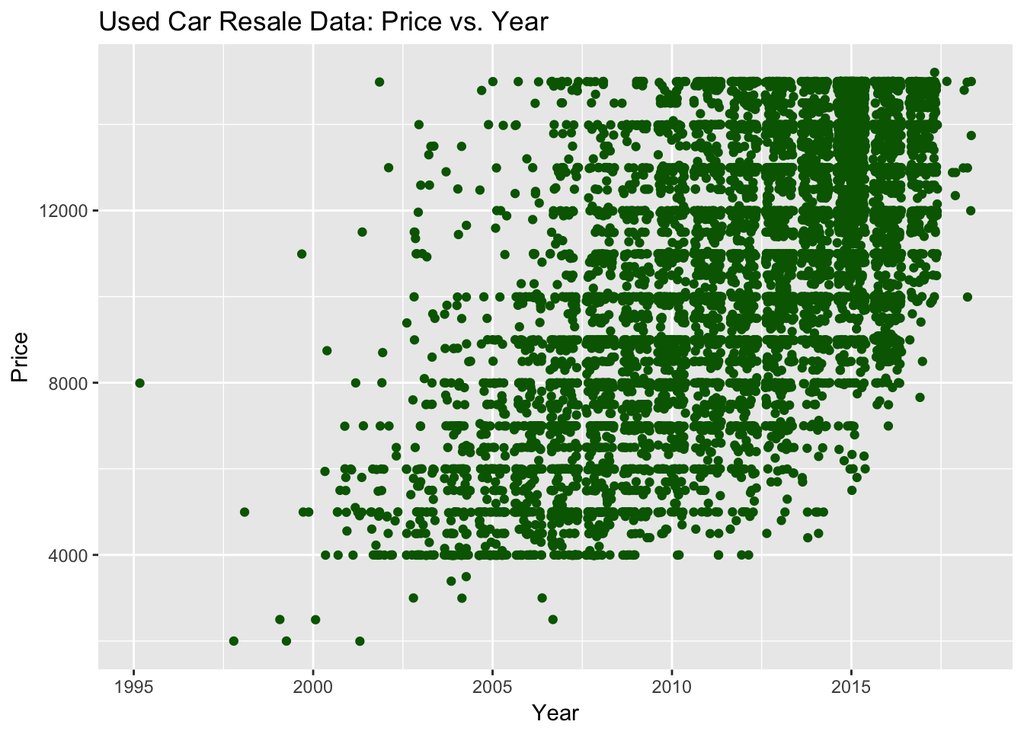

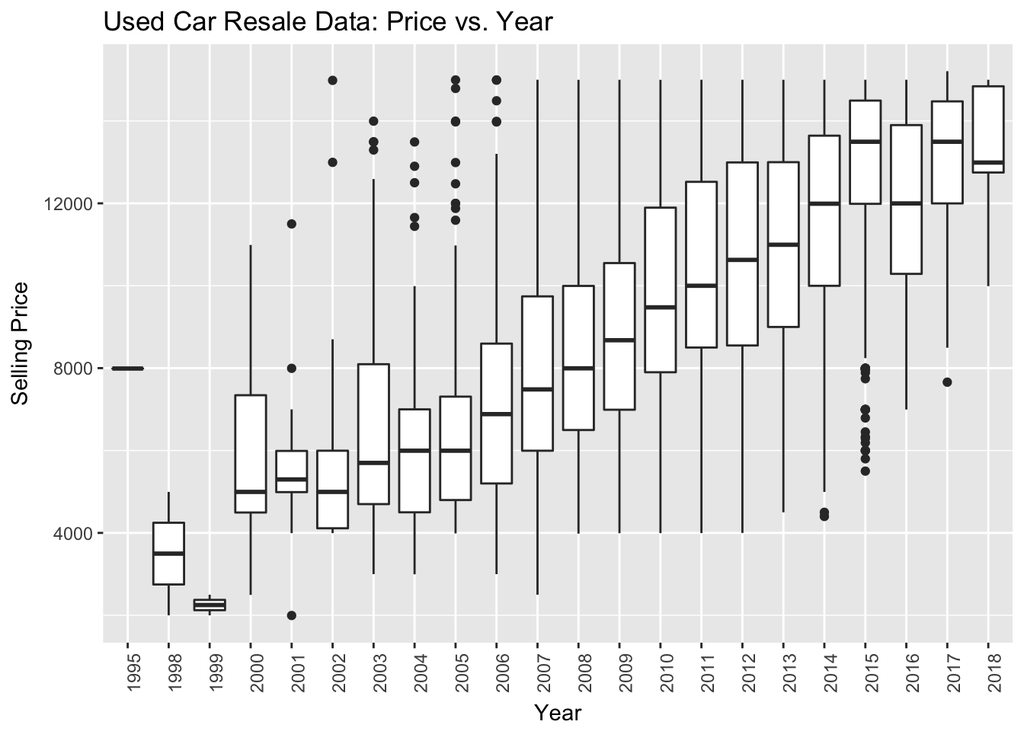

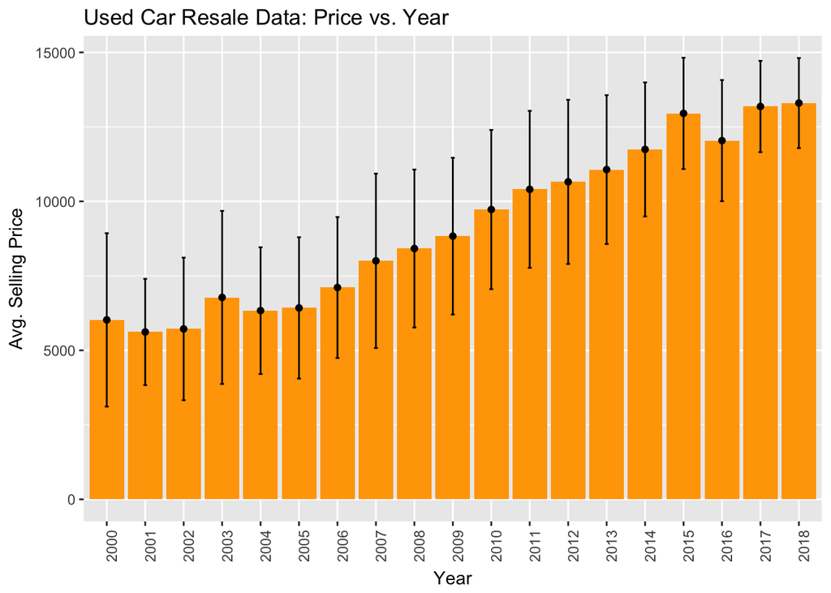

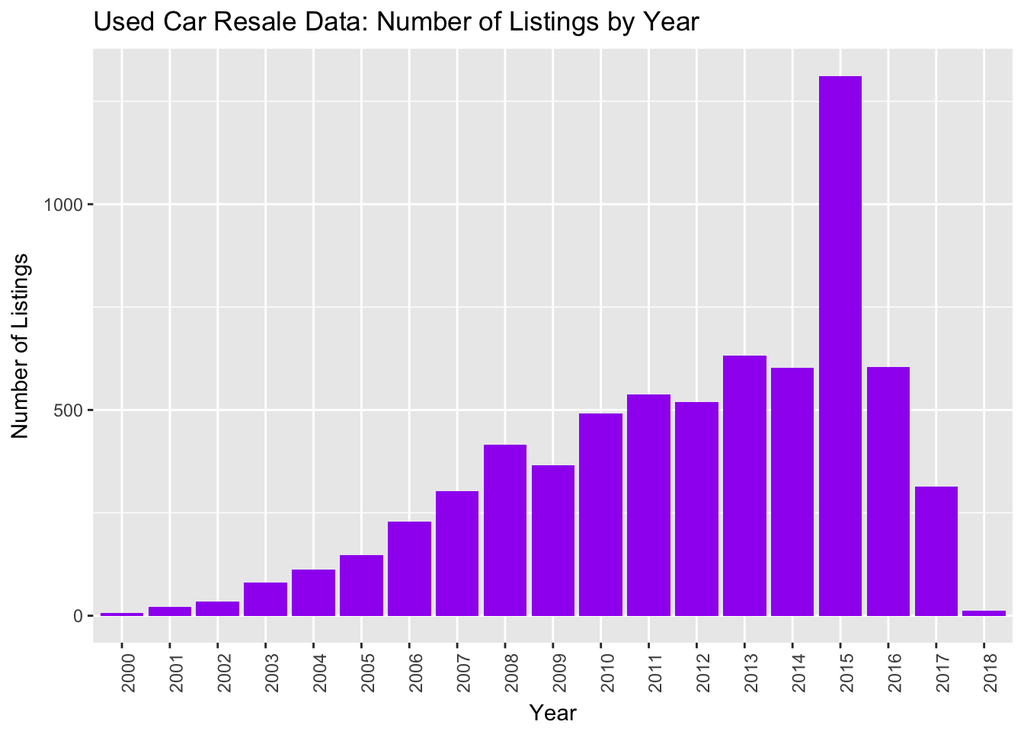

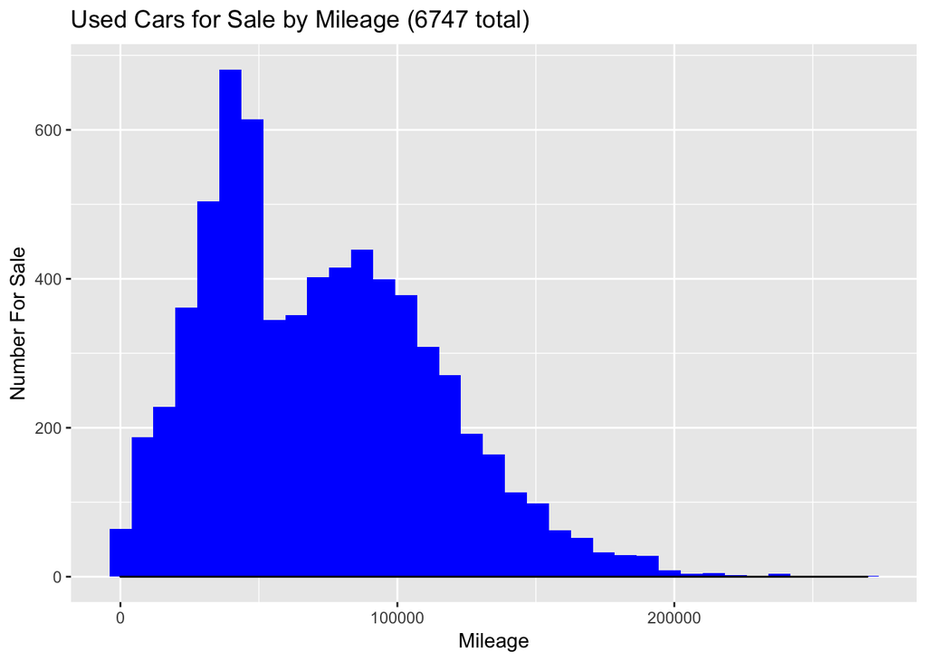

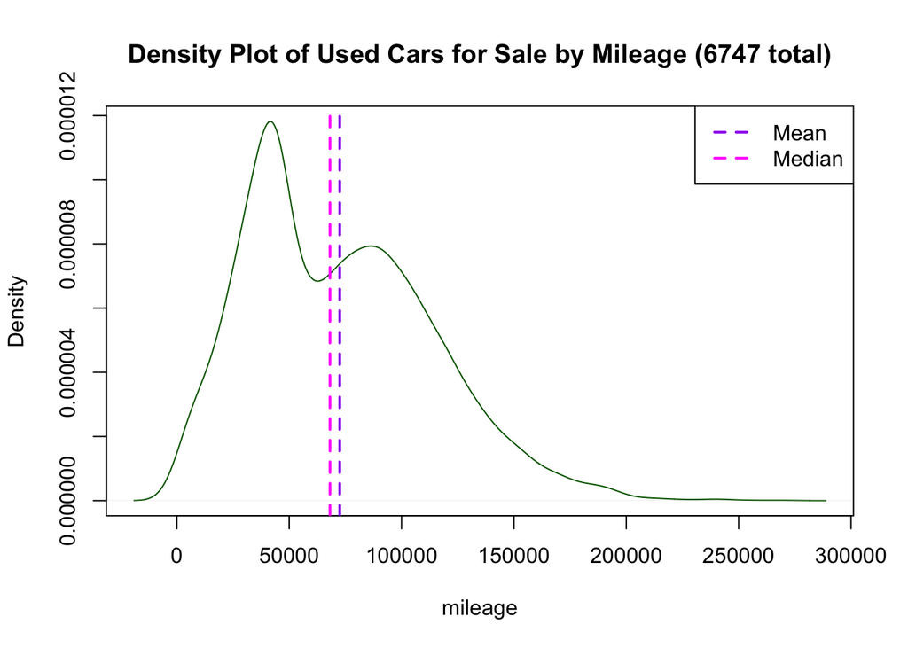

```
##    meanval medianval     std
## 1 72484.35     68155 41156.2
```

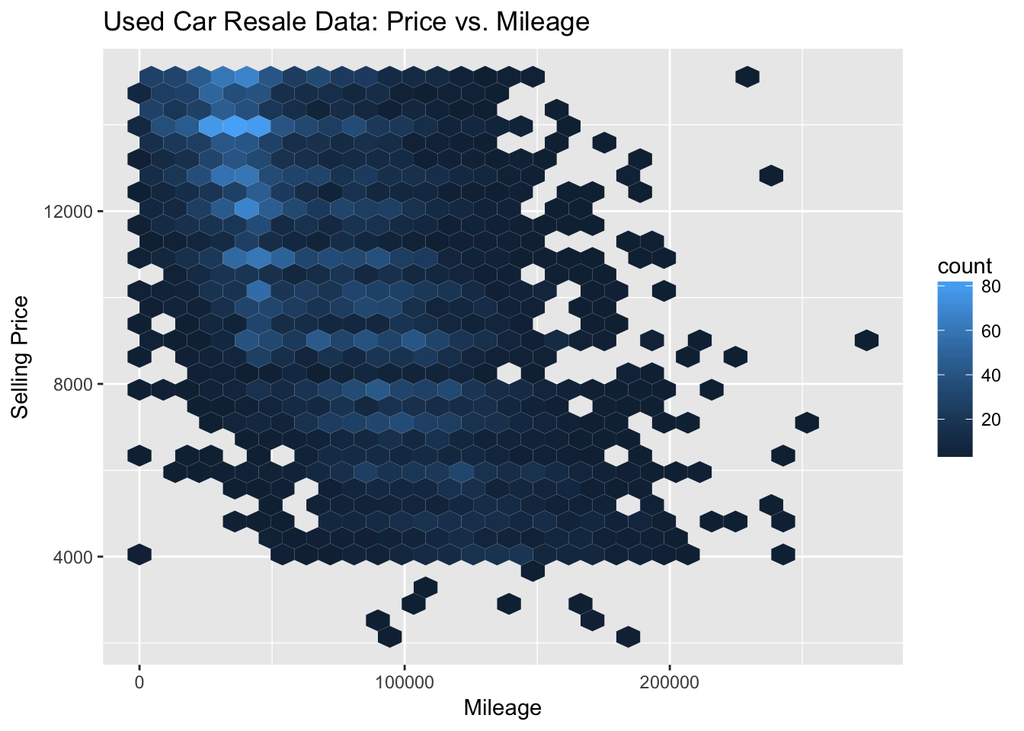

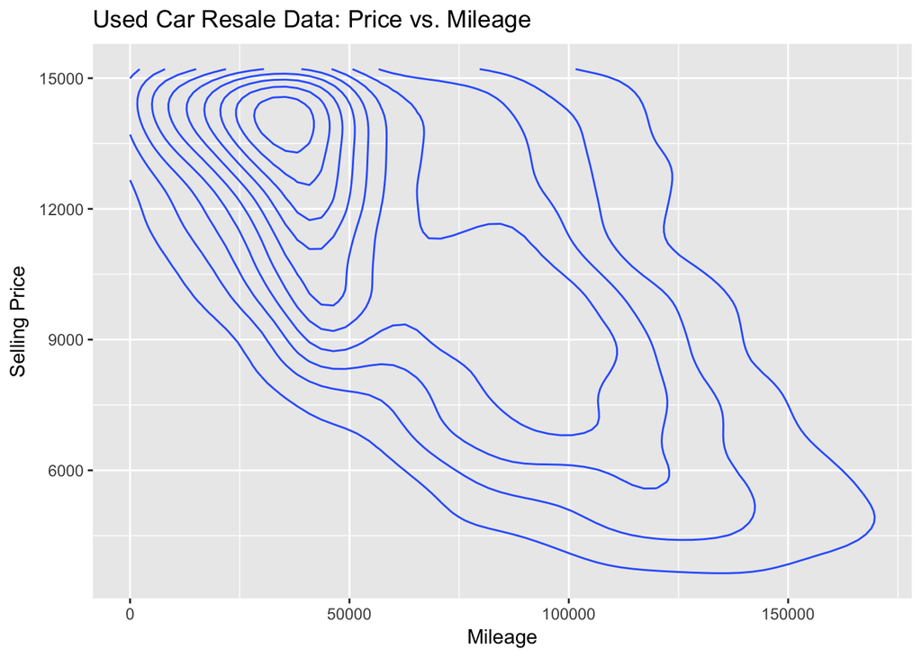

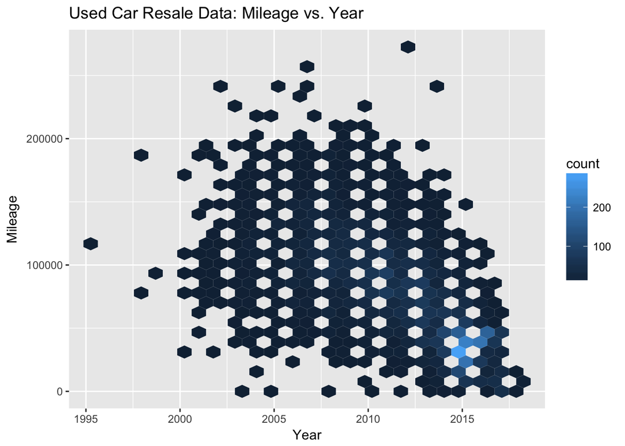

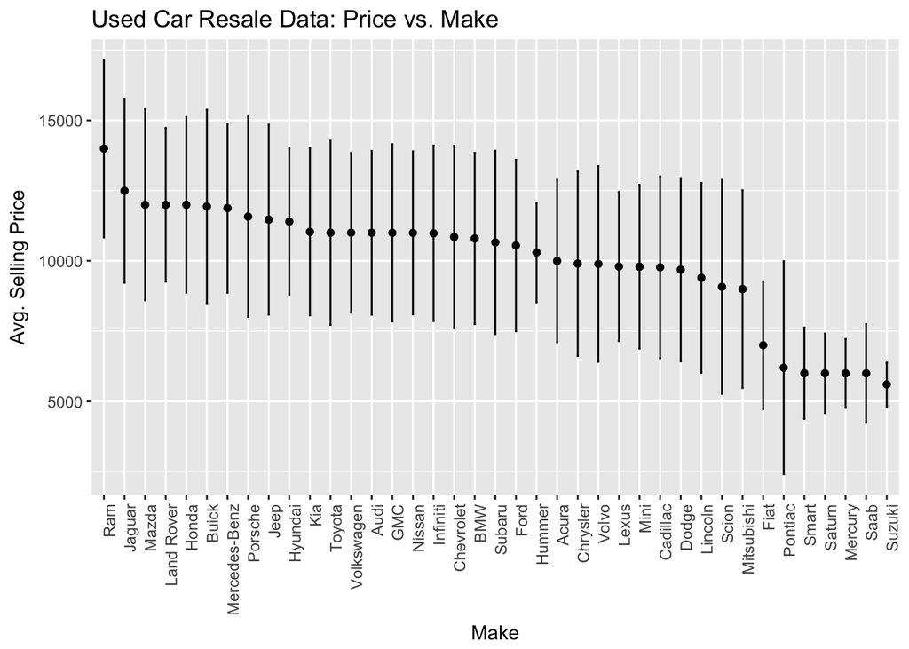

```
##             make medianval       std
## 1            Ram   13995.0 3162.5919
## 2         Jaguar   12495.0 3276.3215
## 3          Mazda   11997.0 3402.4451
## 4     Land Rover   11995.0 2739.5943
## 5          Honda   11994.0 3125.9311
## 6          Buick   11938.0 3444.4390
## 7  Mercedes-Benz   11877.0 3014.2723
## 8        Porsche   11575.0 3567.6272
## 9           Jeep   11467.0 3379.7847
## 10       Hyundai   11399.0 2600.1233
## 11           Kia   11033.0 2973.5412
## 12        Toyota   10999.0 3280.6603
## 13    Volkswagen   10999.0 2844.6444
## 14          Audi   10998.0 2916.1142
```

[output cut: 25 more lines]

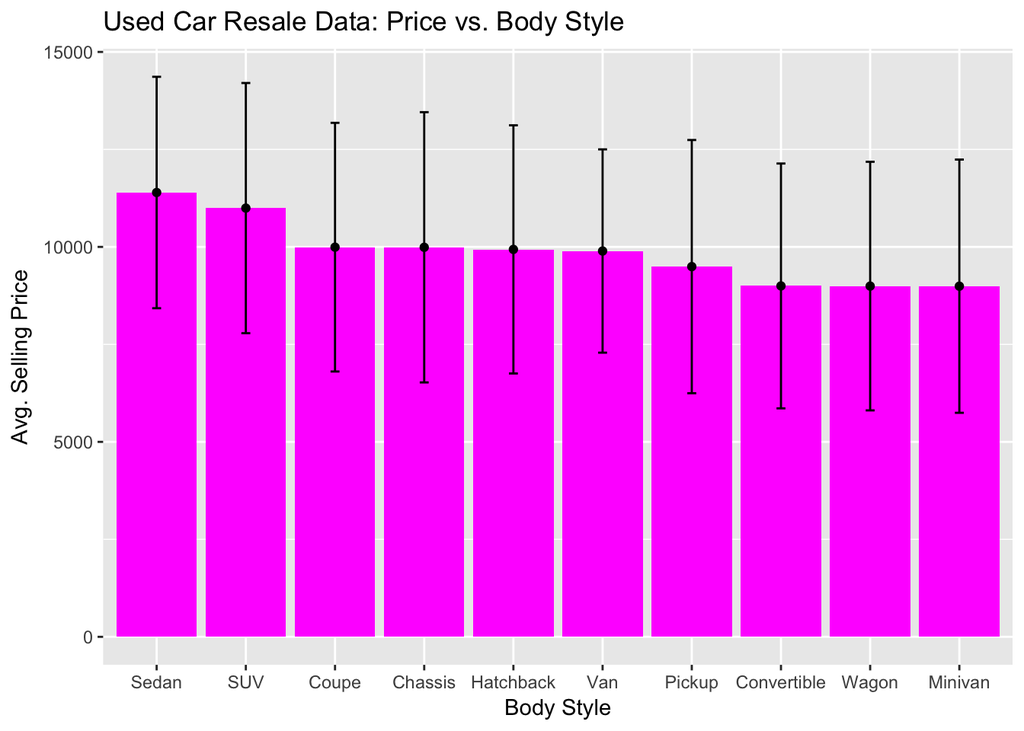

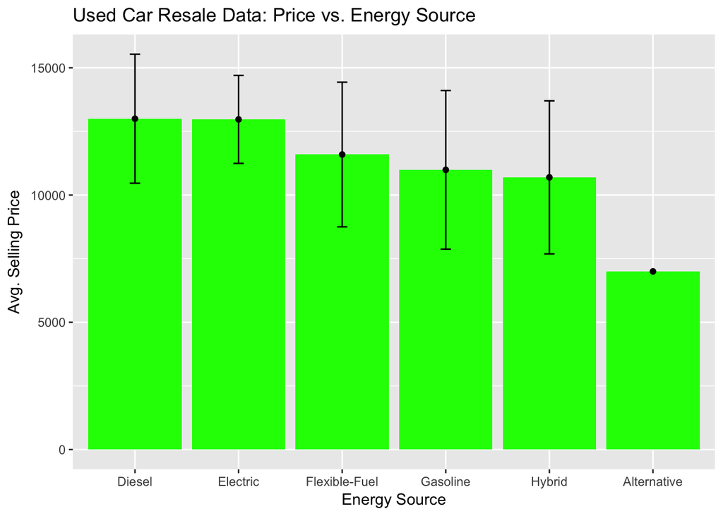

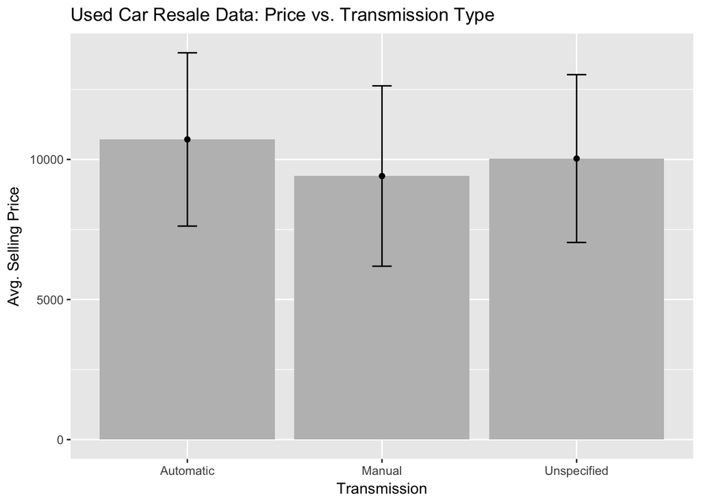

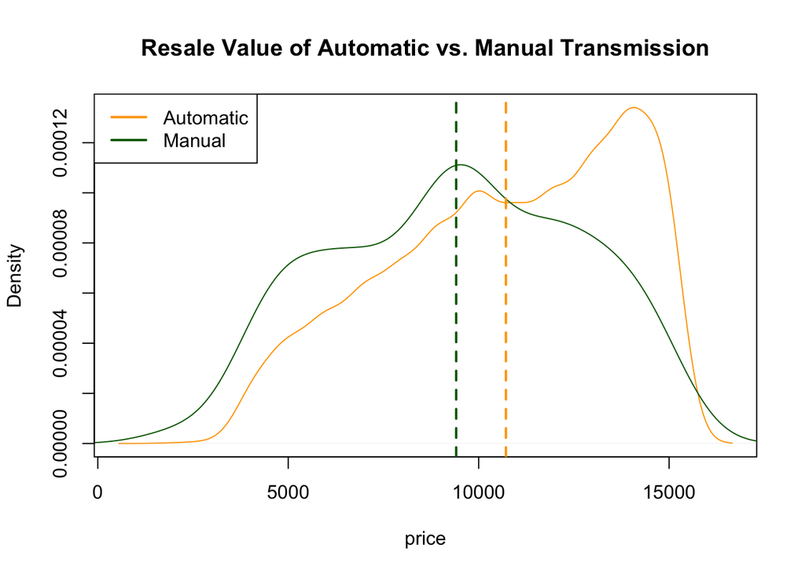

```
##
##  Welch Two Sample t-test
##
## data:  withautomatic and withmanual
## t = 6.4112, df = 277.62, p-value = 0.0000000006181
## alternative hypothesis: true difference in means is not equal to 0
## 95 percent confidence interval:
##   905.0155 1707.0337
## sample estimates:
## mean of x mean of y
## 10714.936  9408.911
```

[figure not shown]

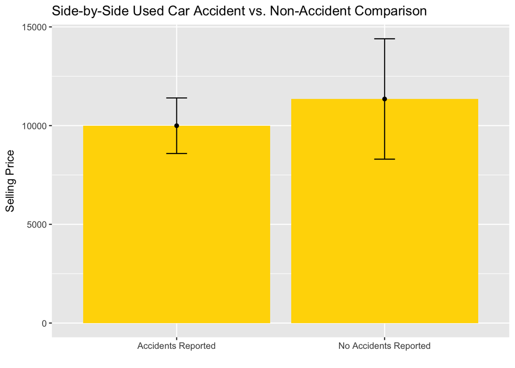

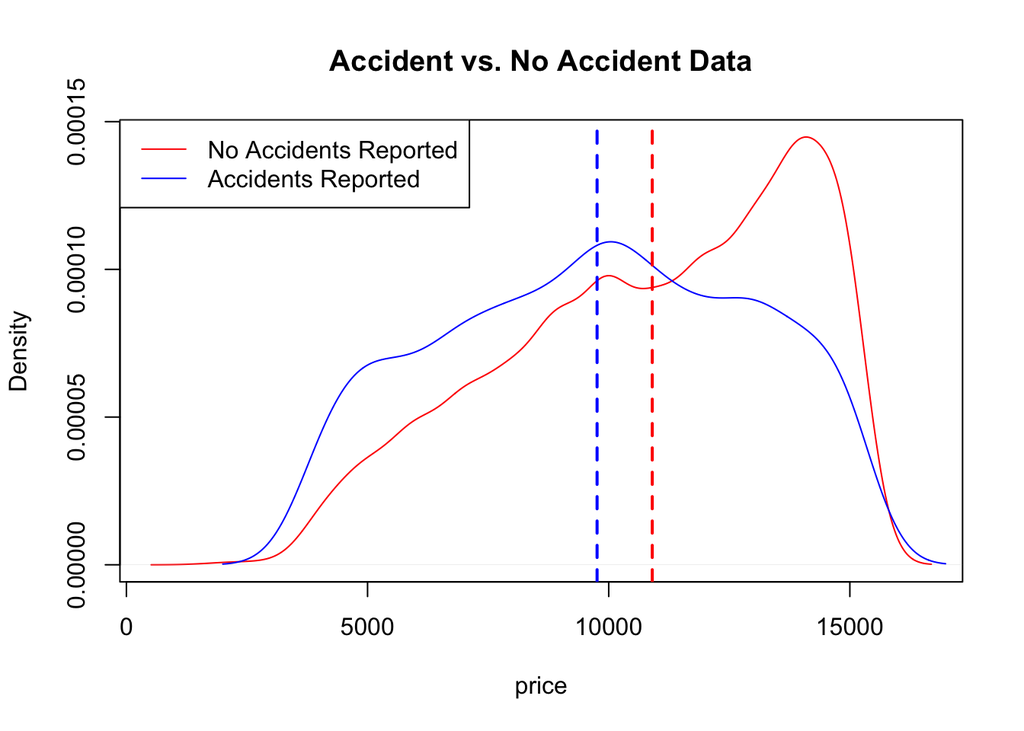

```
##
##  Welch Two Sample t-test
##
## data:  withaccident and withoutaccident
## t = -12.344, df = 2258.4, p-value < 2.2e-16
## alternative hypothesis: true difference in means is not equal to 0
## 95 percent confidence interval:
##  -1325.6244  -962.1869
## sample estimates:
## mean of x mean of y
##  9758.947 10902.853
```

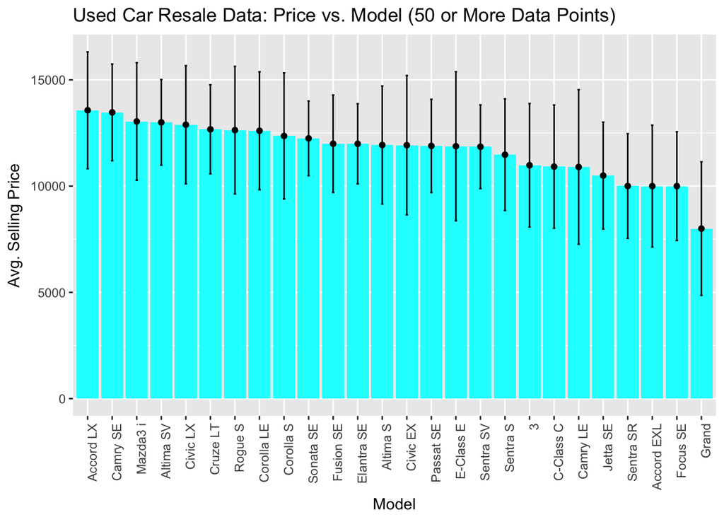

## Conclusions:

Interesting fact: Gold color cars resell the worst of all exterior colors.

These results can be applied not only for those who are interested in purchasing a used car, but also for:

- Those considering purchasing a new car.
- Whether or not to buy or lease a new car.
- Whether to sell a currently owned used car or keep it.